# LGBTQI+ Hate Crime Analysis — 02: Exploratory Data Analysis

## Chart 06 — Top 15 States by Total Incidents

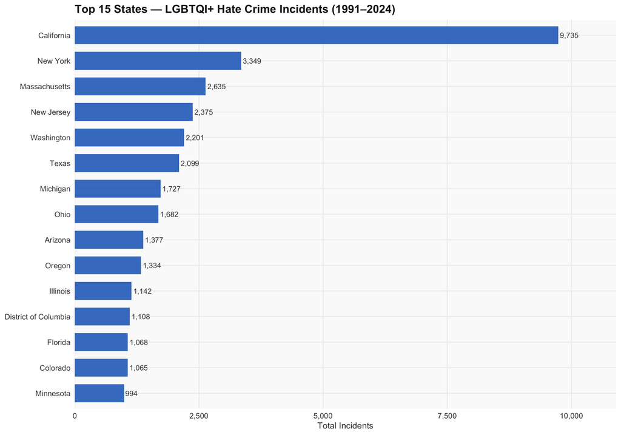

```r
top_states <- sy |>
  group_by(STATE_NAME) |>
  summarise(TOTAL_INCIDENTS = sum(INCIDENTS, na.rm = TRUE), .groups = "drop") |>
  slice_max(TOTAL_INCIDENTS, n = 15) |>
  mutate(STATE_NAME = fct_reorder(STATE_NAME, TOTAL_INCIDENTS))

p06 <- ggplot(top_states, aes(x = TOTAL_INCIDENTS, y = STATE_NAME)) +
  geom_col(fill = "#1565C0", alpha = 0.85, width = 0.7) +
  geom_text(aes(label = comma(TOTAL_INCIDENTS)),
            hjust = -0.1, size = 3, colour = "#444444") +
  scale_x_continuous(labels = comma, expand = expansion(mult = c(0, 0.12))) +
  labs(title = "Top 15 States — LGBTQI+ Hate Crime Incidents (1991–2024)",
       x = "Total Incidents", y = NULL) +
  theme_hate()

p06
```

```r
save_chart(p06, "06_top_states.png", width = 9, height = 7)
```

## Chart 07 — Incident Rate by Law Coverage Level

A counterintuitive but well-documented pattern: states *with* hate crime laws covering LGBTQI+ characteristics report **higher** incident rates — not because they have more hate crimes, but because legal frameworks create accountability structures that improve classification and reporting. This is the **reporting effect**.

This chart uses **Track 2 (per 100k LGBT residents, 2012–2024)** and a **time-varying law level** — each state × year observation gets the law coverage actually in effect that year.

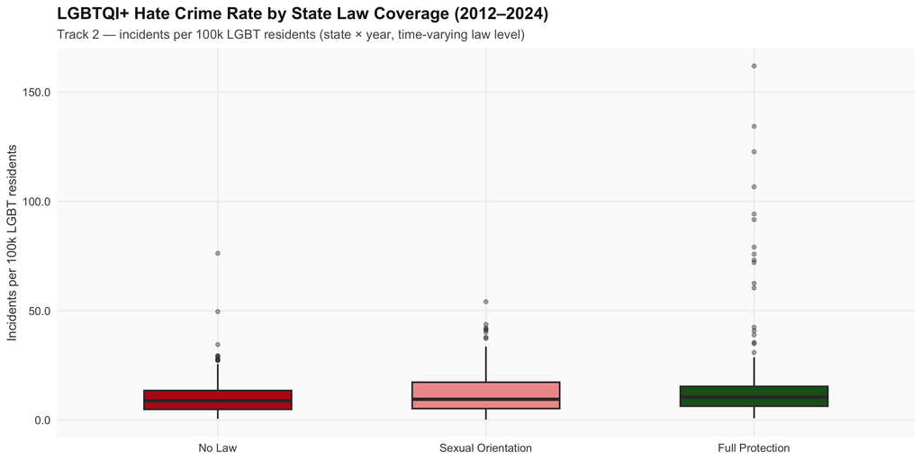

```r
if (!is.null(law_lookup)) {
  sy_law <- sy |>
    filter(DATA_YEAR >= 2012, !is.na(RATE_PER_100K_LGBT)) |>
    select(-any_of(c("LAW_LEVEL", "HC_LAW_SO", "HC_LAW_GI"))) |>
    left_join(law_lookup, by = c("STATE_NAME", "DATA_YEAR")) |>
    filter(!is.na(LAW_LEVEL)) |>
    mutate(LAW_LABEL = factor(
      case_when(
        LAW_LEVEL == 0 ~ "No Law",
        LAW_LEVEL == 1 ~ "Sexual Orientation",
        LAW_LEVEL == 2 ~ "Full Protection"
      ),
      levels = c("No Law", "Sexual Orientation", "Full Protection")
    ))

  p07 <- ggplot(sy_law, aes(x = LAW_LABEL, y = RATE_PER_100K_LGBT, fill = LAW_LABEL)) +
    geom_boxplot(outlier.size = 1.2, outlier.alpha = 0.4, width = 0.55, linewidth = 0.6) +
    scale_fill_manual(values = LAW_COLORS, guide = "none") +
    scale_y_continuous(labels = number_format(accuracy = 0.1)) +
    labs(title    = "LGBTQI+ Hate Crime Rate by State Law Coverage (2012–2024)",
         subtitle = "Track 2 — incidents per 100k LGBT residents (state × year, time-varying law level)",
         x = NULL, y = "Incidents per 100k LGBT residents") +
    theme_hate()

  print(p07)
  save_chart(p07, "07_law_impact_boxplot.png", width = 9, height = 5)
} else {
  cat("Chart 07 skipped — state_law_panel.csv not available.\n")
}
```

## Chart 08 — Seasonality Heatmap

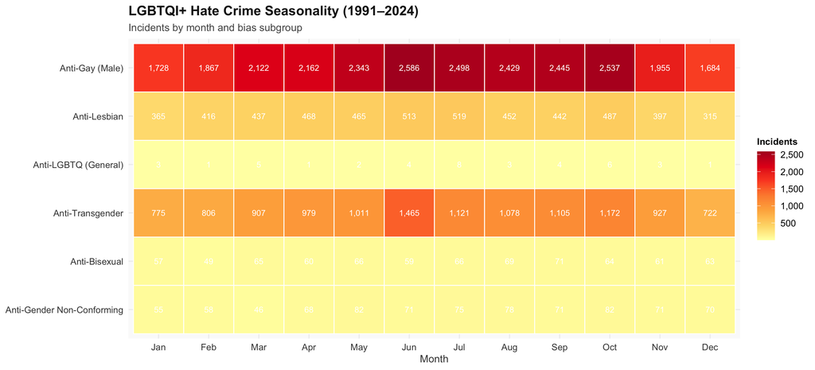

```r
month_levels <- c("Jan","Feb","Mar","Apr","May","Jun",
                  "Jul","Aug","Sep","Oct","Nov","Dec")

heat_data <- full |>
  filter(BIAS_CATEGORY %in% names(BIAS_COLORS), !is.na(MONTH_NAME)) |>
  count(MONTH_NAME, BIAS_CATEGORY, name = "INCIDENTS") |>
  mutate(MONTH_NAME = factor(MONTH_NAME, levels = month_levels))

p08 <- ggplot(heat_data, aes(x = MONTH_NAME, y = BIAS_CATEGORY, fill = INCIDENTS)) +
  geom_tile(colour = "white", linewidth = 0.4) +
  geom_text(aes(label = comma(INCIDENTS, accuracy = 1)),
            size = 2.8, colour = "white") +
  scale_fill_distiller(palette = "YlOrRd", direction = 1, labels = comma, name = "Incidents") +
  scale_y_discrete(limits = rev(names(BIAS_COLORS))) +
  labs(title    = "LGBTQI+ Hate Crime Seasonality (1991–2024)",
       subtitle = "Incidents by month and bias subgroup",
       x = "Month", y = NULL) +
  theme_hate() + theme(panel.grid = element_blank())

p08
```

```r
save_chart(p08, "08_seasonality_heatmap.png", width = 11, height = 5)
```

## Chart 09 — Gini Coefficient vs. Incident Rate (Two-Track)

Income inequality (Gini coefficient) is the strongest predictor of LGBTQI+ hate crime rates. The correlation holds across both normalisation tracks, though the relationship is somewhat attenuated in Track 2 (per LGBT residents) because high-Gini states also tend to have smaller visible LGBT populations.

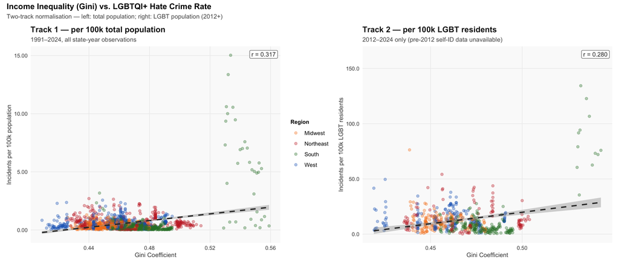

```r
sy_t1 <- sy |>
  filter(!is.na(GINI_COEFFICIENT), !is.na(RATE_PER_100K_TOTAL),
         !is.na(REGION_NAME), REGION_NAME %in% names(REGION_COLORS))

r1 <- cor(sy_t1$GINI_COEFFICIENT, sy_t1$RATE_PER_100K_TOTAL, use = "complete.obs")

p09a <- ggplot(sy_t1, aes(x = GINI_COEFFICIENT, y = RATE_PER_100K_TOTAL,
                            colour = REGION_NAME)) +
  geom_point(alpha = 0.35, size = 1.8) +
  geom_smooth(method = "lm", se = TRUE, colour = "#333333",
              linewidth = 1, linetype = "dashed", inherit.aes = FALSE,
              aes(x = GINI_COEFFICIENT, y = RATE_PER_100K_TOTAL)) +
  scale_colour_manual(values = REGION_COLORS, name = "Region") +
  scale_y_continuous(labels = number_format(accuracy = 0.01)) +
  annotate("label", x = Inf, y = Inf, hjust = 1.1, vjust = 1.5,
           label = sprintf("r = %.3f", r1), size = 3.5, fill = "white", colour = "#333333") +
  labs(title    = "Track 1 — per 100k total population",
       subtitle = "1991–2024, all state-year observations",
       x = "Gini Coefficient", y = "Incidents per 100k population") +
  theme_hate()

sy_t2 <- sy |>
  filter(!is.na(GINI_COEFFICIENT), !is.na(RATE_PER_100K_LGBT),
         !is.na(REGION_NAME), REGION_NAME %in% names(REGION_COLORS),
         DATA_YEAR >= 2012)

if (nrow(sy_t2) >= 5) {
  r2 <- cor(sy_t2$GINI_COEFFICIENT, sy_t2$RATE_PER_100K_LGBT, use = "complete.obs")

  p09b <- ggplot(sy_t2, aes(x = GINI_COEFFICIENT, y = RATE_PER_100K_LGBT,
                              colour = REGION_NAME)) +
    geom_point(alpha = 0.35, size = 1.8) +
    geom_smooth(method = "lm", se = TRUE, colour = "#333333",
                linewidth = 1, linetype = "dashed", inherit.aes = FALSE,
                aes(x = GINI_COEFFICIENT, y = RATE_PER_100K_LGBT)) +
    scale_colour_manual(values = REGION_COLORS, name = "Region") +
    scale_y_continuous(labels = number_format(accuracy = 0.1)) +
    annotate("label", x = Inf, y = Inf, hjust = 1.1, vjust = 1.5,
             label = sprintf("r = %.3f", r2), size = 3.5, fill = "white", colour = "#333333") +
    labs(title    = "Track 2 — per 100k LGBT residents",
         subtitle = "2012–2024 only (pre-2012 self-ID data unavailable)",
         x = "Gini Coefficient", y = "Incidents per 100k LGBT residents") +
    theme_hate() + theme(legend.position = "none")

  p09 <- (p09a + p09b) +
    plot_annotation(
      title    = "Income Inequality (Gini) vs. LGBTQI+ Hate Crime Rate",
      subtitle = "Two-track normalisation — left: total population; right: LGBT population (2012+)",
      theme    = theme(plot.title    = element_text(face = "bold", size = 13),
                       plot.subtitle = element_text(size = 10, colour = "#555555"))
    )
  print(p09)
  save_chart(p09, "09_gini_vs_rate.png", width = 14, height = 6)
} else {
  print(p09a)
  save_chart(p09a, "09_gini_vs_rate.png", width = 9, height = 6)
}
```